# Bihar TV penetration

2022-07-20

### Background: The data has 44098 cases for state Bihar where each case is a area in the state. The “percentage of households having TV” is a target variable. The data has many other variables related to condition of houses, ownership status,facilities etc.which can influence the TV penetration in the specific area.

### The objective is to identify significant factors affecting TV penetration.

#### Data Description

| Column name | Column description |
| --- | --- |
| liv_house | Percentage of total houses having livable condition |
| owned | Percentage of owned houses |
| elect_light | Percentage of houses having main source of light as electricity |
| lat_inprem | Percentage of houses having latrine facility |
| perm | Percentag of permanent houses |
| atlone_rm | Percentage of houses having atleast one dwelling room |
| atlthr_mem | Percentage of houses having atleast three members |
| atlone_cou | Percentage of houses having atleast one couple |
| bath | Percentage of houses having bathroom with or without roof |
| kitchen | Percentage of houses having kitchen inside or outside house |

#### Import data of Bihar state combining all 38 districts

```r
library(readxl)
data=read_excel("Araria filtered.xlsx")

data.files = list.files(pattern = "*.xlsx")

i=2
lst<-list()
for (i in 2:length(data.files)) {
  lst[[i]]<- read_excel(data.files[i],skip=6)
  names(lst[[i]])<-names(data)
}

lst2<-lst[lapply(lst,length)>0]

bihardata<-do.call(rbind,lst2)
bihardata<-rbind(data,bihardata)
head(data.frame(bihardata))
```

```
  st_code st_name dist_code dist_name teh_code   teh_name town_code ward_no
1      10   BIHAR       209    Araria    00000     Araria    000000    0000
2      10   BIHAR       209    Araria    00000     Araria    000000    0000
3      10   BIHAR       209    Araria    00000     Araria    000000    0000
4      10   BIHAR       209    Araria    01112 Narpatganj    000000    0000
5      10   BIHAR       209    Araria    01112 Narpatganj    000000    0000
6      10   BIHAR       209    Araria    01112 Narpatganj    221471    0000
                   area is_rural t_house good_house liv_house dil_house t_res
1     District - Araria    Total     100       32.7      63.5       3.8  97.8
2     District - Araria    Rural     100       31.9      64.4       3.7  97.9
3     District - Araria    Urban     100       45.1      48.5       6.4  96.1
4 Sub-Dist - Narpatganj    Total     100       25.2      68.4       6.4  97.2
5 Sub-Dist - Narpatganj    Rural     100       25.2      68.4       6.4  97.2
6                Parasi    Rural     100       31.8      63.5       4.7  99.3
  good_res liv_res dil_res t_oth good_oth liv_oth dil_oth gra_roof poly_roof
```

[output cut: 111 more lines]

#### Creating columns atlone_rm by adding columns one room and above, atlthr_mem by adding columns three members and above , atlone_cou by adding columns one couple and above , bath by adding columns bathroom with roof nad without roof, kitchen by adding columns cooking inside and outside house

```r
bihardata$atlone_rm=rowSums(bihardata[,c("one_rm","two_ rm","thr_rm","four_rm","five_rm","msix_rm")])


bihardata$atlthr_mem=rowSums(bihardata[,c("thr_mem","four_mem","five_mem","sixeig_mem","mnine_mem")])


bihardata$atlone_cou=rowSums(bihardata[,c("one_cou","two_cou","thr_cou","four_cou","mfive_cou")])


bihardata$bath=rowSums(bihardata[,c("y_bath","yn_bath")])

bihardata$kitchen=rowSums(bihardata[,c("yin_kit","yout_kit")])
```

#### Identify the variables and produce correlation matrix

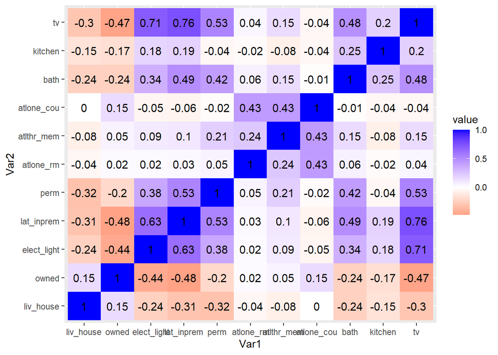

```r
library(reshape2)
cormat <- round(cor(bihardata[,c("liv_house","owned","elect_light","lat_inprem","perm","atlone_rm","atlthr_mem","atlone_cou","bath","kitchen","tv")]),2)
melted_cormat <- melt(cormat)

ggplot(data = melted_cormat, aes(x=Var1, y=Var2, fill=value)) +
  geom_tile()+
  geom_text(aes(Var2, Var1, label = value), color = "black", size = 4)+
  scale_fill_gradient2(low="red",mid="white",high="blue")
```

#### Split original data into training and testing data sets for Bihar state

```r
index<-createDataPartition(bihardata$tv,p=0.8,list=FALSE)

traindata<-bihardata[index,]
testdata<-bihardata[-index,]
```

#### Linear Regression using lm function

```r
hp_model<-lm(tv~liv_house+owned+elect_light+lat_inprem+perm+atlone_rm+atlthr_mem+atlone_cou+bath+kitchen,data=traindata)
```

#### Display parameter estimates with other model statistics

```r
summary(hp_model)
```

```
Call:
lm(formula = tv ~ liv_house + owned + elect_light + lat_inprem +
    perm + atlone_rm + atlthr_mem + atlone_cou + bath + kitchen,
    data = traindata)

Residuals:
    Min      1Q  Median      3Q     Max
-75.578  -4.182  -0.597   3.212 112.577

Coefficients:
             Estimate Std. Error t value Pr(>|t|)
(Intercept)  9.542445   1.073086   8.893  < 2e-16 ***
liv_house   -0.009658   0.002086  -4.630 3.67e-06 ***
owned       -0.211535   0.007612 -27.790  < 2e-16 ***
elect_light  0.230686   0.002577  89.524  < 2e-16 ***
lat_inprem   0.282371   0.003332  84.737  < 2e-16 ***
perm         0.083742   0.002300  36.410  < 2e-16 ***
atlone_rm    0.005301   0.007347   0.722    0.471
atlthr_mem   0.117728   0.007578  15.536  < 2e-16 ***
atlone_cou  -0.012828   0.007798  -1.645    0.100 .
bath         0.040513   0.002034  19.913  < 2e-16 ***
kitchen      0.023047   0.001772  13.006  < 2e-16 ***
---
Signif. codes:  0 '***' 0.001 '**' 0.01 '*' 0.05 '.' 0.1 ' ' 1

Residual standard error: 8.485 on 35269 degrees of freedom
Multiple R-squared:  0.7044,    Adjusted R-squared:  0.7043
F-statistic:  8403 on 10 and 35269 DF,  p-value: < 2.2e-16
```

#### Comment:“atlone_rm” and “atlone_cou” are insignificant variables

#### The model explains 70% of variation in dependent variable

#### Check for multicollinearity using vif function

```r
vif(hp_model)
```

```
  liv_house       owned elect_light  lat_inprem        perm   atlone_rm
   1.176189    1.390150    1.758299    2.366145    1.644896    1.227471
 atlthr_mem  atlone_cou        bath     kitchen
   1.344153    1.484537    1.485105    1.163894
```

#### Comment : As all VIF’s are less than 5 ,Multicollinearity is not present in a model

#### Plot of Residuals vs Predicted values

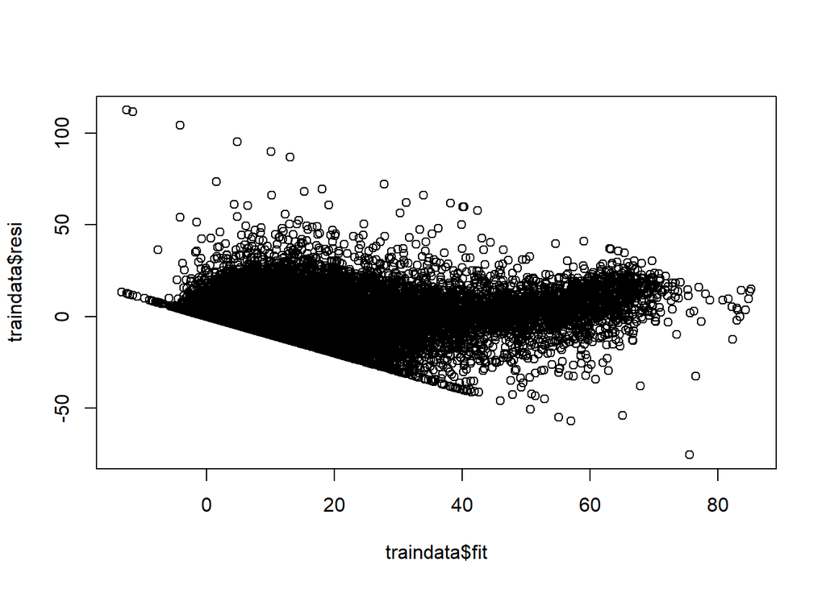

```r
traindata$fit<-fitted(hp_model)
traindata$resi<-residuals(hp_model)
plot(traindata$fit,traindata$resi)
```

#### Check if distribution of errors is “NORMAL”

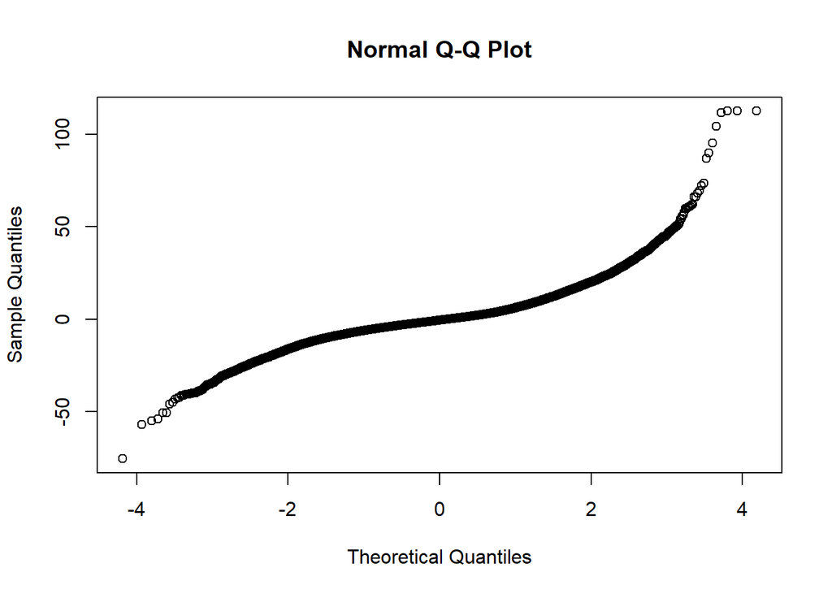

```r
qqnorm(traindata$resi)
```

```r
lillie.test(traindata$resi)
```

```
    Lilliefors (Kolmogorov-Smirnov) normality test

data:  traindata$resi
D = 0.10311, p-value < 2.2e-16
```

#### Comment: Although normality of errors is not established we will proceed to evaluate the model performance

#### Rerun the model after removing the insignificant variables

```r
hp_model2<-lm(tv~liv_house+owned+elect_light+lat_inprem+perm+atlthr_mem+bath+kitchen,data=traindata)
summary(hp_model2)
```

```
Call:
lm(formula = tv ~ liv_house + owned + elect_light + lat_inprem +
    perm + atlthr_mem + bath + kitchen, data = traindata)

Residuals:
    Min      1Q  Median      3Q     Max
-75.491  -4.184  -0.598   3.212 112.834

Coefficients:
             Estimate Std. Error t value Pr(>|t|)
(Intercept)  9.416817   0.930338  10.122  < 2e-16 ***
liv_house   -0.009629   0.002086  -4.617 3.91e-06 ***
owned       -0.212875   0.007567 -28.131  < 2e-16 ***
elect_light  0.230714   0.002577  89.545  < 2e-16 ***
lat_inprem   0.282406   0.003332  84.752  < 2e-16 ***
perm         0.084027   0.002293  36.642  < 2e-16 ***
atlthr_mem   0.112952   0.006792  16.630  < 2e-16 ***
bath         0.040612   0.002033  19.975  < 2e-16 ***
kitchen      0.022985   0.001772  12.974  < 2e-16 ***
---
Signif. codes:  0 '***' 0.001 '**' 0.01 '*' 0.05 '.' 0.1 ' ' 1

Residual standard error: 8.486 on 35271 degrees of freedom
Multiple R-squared:  0.7043,    Adjusted R-squared:  0.7043
F-statistic: 1.05e+04 on 8 and 35271 DF,  p-value: < 2.2e-16
```

#### Calculate RMSE values based on residuals using first principle

```r
traindata$resi<-residuals(hp_model2)

RMSE<-sqrt(mean(traindata$resi**2))
RMSE
```

```
[1] 8.484495
```

#### Model Validation: Holdout Method using RMSE

```r
testdata$pred<-predict(hp_model2,testdata)
testdata$res<-(testdata$tv-testdata$pred)
RMSEtest<-sqrt(mean(testdata$res**2))
RMSEtest
```

```
[1] 8.717205
```

#### Comment: RMSE values for train and test data are similar hence the model can be implemented for decision making for Bihar state

#### Converting continuous variables into categorical variables by using quantile function

```r
bihardata$TV<-cut(bihardata$tv,quantile(bihardata$tv),include.lowest=TRUE,labels=c("very low","low","moderate","high"))
bihardata$livable<-cut(bihardata$liv_house,quantile(bihardata$liv_house),include.lowest=TRUE,labels=c("very low","low","moderate","high"))

bihardata$owner <- as.factor(ntile(bihardata$owned, 4))
levels(bihardata$owner) <- c("very low","low","moderate","high")

bihardata$electr <- as.factor(ntile(bihardata$elect_light, 4))
levels(bihardata$electr) <- c("very low","low","moderate","high")

bihardata$latrine<-cut(bihardata$lat_inprem,quantile(bihardata$lat_inprem),include.lowest=TRUE,labels=c("very low","low","moderate","high"))
bihardata$perman<-cut(bihardata$perm,quantile(bihardata$perm),include.lowest=TRUE,labels=c("very low","low","moderate","high"))
bihardata$membr<-cut(bihardata$atlthr_mem,quantile(bihardata$atlthr_mem),include.lowest=TRUE,labels=c("very low","low","moderate","high"))
bihardata$bathrm<-cut(bihardata$bath,quantile(bihardata$bath),include.lowest=TRUE,labels=c("very low","low","moderate","high"))
bihardata$kit<-cut(bihardata$kitchen,quantile(bihardata$kitchen),include.lowest=TRUE,labels=c("very low","low","moderate","high"))

bihar1=data.frame(bihardata$TV,bihardata$livable,bihardata$owner,bihardata$electr,bihardata$latrine,bihardata$perman,bihardata$membr,bihardata$bathrm,bihardata$kit)
names(bihar1)=c("TV","livable","owner","electr","latrine","perman","membr","bathrm","kit")

lst<-list()
i=1
for (i in 1:8){

  a<-as.data.frame.matrix(table(bihar1$TV,bihar1[,i+1]))
  a2<-as.data.frame.matrix(round(prop.table(table(bihar1$TV,bihar1[,i+1]))*100,2))
  for (j in 1:4){
    a[,j]<-paste(a[,j]," (",a2[,j],"%)",sep = "")
  }
  a$New<-c("very low","low","moderate","high")

  a<-a[,c(5,1:4)]
  names(a)[1]<-paste("TV & ",names(bihar1)[i+1],sep = "")
  lst[[i]]<-a
  names(lst)[i]<-names(bihar1)[i+1]

}

std_border = fp_border(color="black", width = 1)
lst[[1]] %>% flextable() %>%
  set_caption(caption = "TV vs liv_house",autonum = NULL,
  style = "Table Caption",
  html_escape = TRUE) %>%
  border_inner(border = std_border) %>%
  border_outer(border = std_border) %>%
  bold(bold = T,part = "header") %>%
  autofit()
```

TV vs liv_house

| TV & livable | very low | low | moderate | high |
| --- | --- | --- | --- | --- |
| very low | 2277 (5.16%) | 1654 (3.75%) | 2226 (5.05%) | 4886 (11.08%) |
| low | 2084 (4.73%) | 2678 (6.07%) | 3521 (7.98%) | 2837 (6.43%) |
| moderate | 2310 (5.24%) | 3330 (7.55%) | 3244 (7.36%) | 2070 (4.69%) |
| high | 4354 (9.87%) | 3415 (7.74%) | 2028 (4.6%) | 1184 (2.68%) |

```r
lst[[2]] %>% flextable() %>%
  set_caption(caption = "TV vs Owned",autonum = NULL,
  style = "Table Caption",
  html_escape = TRUE) %>%
  border_inner(border = std_border) %>%
  border_outer(border = std_border) %>%
  bold(bold = T,part = "header") %>%
  autofit()
```

TV vs Owned

| TV & owner | very low | low | moderate | high |
| --- | --- | --- | --- | --- |
| very low | 1586 (3.6%) | 2071 (4.7%) | 2977 (6.75%) | 4409 (10%) |
| low | 1936 (4.39%) | 3396 (7.7%) | 3392 (7.69%) | 2396 (5.43%) |
| moderate | 2382 (5.4%) | 3419 (7.75%) | 2961 (6.71%) | 2192 (4.97%) |
| high | 5121 (11.61%) | 2139 (4.85%) | 1694 (3.84%) | 2027 (4.6%) |

```r
lst[[3]] %>% flextable() %>%
  set_caption(caption = "TV vs elect_light",autonum = NULL,
  style = "Table Caption",
  html_escape = TRUE) %>%
  border_inner(border = std_border) %>%
  border_outer(border = std_border) %>%
  bold(bold = T,part = "header") %>%
  autofit()
```

TV vs elect_light

| TV & electr | very low | low | moderate | high |
| --- | --- | --- | --- | --- |
| very low | 6055 (13.73%) | 3289 (7.46%) | 1146 (2.6%) | 553 (1.25%) |
| low | 2590 (5.87%) | 4037 (9.15%) | 3379 (7.66%) | 1114 (2.53%) |
| moderate | 1519 (3.44%) | 2633 (5.97%) | 4276 (9.7%) | 2526 (5.73%) |
| high | 861 (1.95%) | 1066 (2.42%) | 2223 (5.04%) | 6831 (15.49%) |

```r
lst[[4]] %>% flextable() %>%
  set_caption(caption = "TV vs lat_inprem",autonum = NULL,
  style = "Table Caption",
  html_escape = TRUE)  %>%
  border_inner(border = std_border) %>%
  border_outer(border = std_border) %>%
  bold(bold = T,part = "header") %>%
  autofit()
```

TV vs lat_inprem

| TV & latrine | very low | low | moderate | high |
| --- | --- | --- | --- | --- |
| very low | 6838 (15.51%) | 2704 (6.13%) | 954 (2.16%) | 547 (1.24%) |
| low | 2739 (6.21%) | 4425 (10.03%) | 2923 (6.63%) | 1033 (2.34%) |
| moderate | 1115 (2.53%) | 2859 (6.48%) | 4564 (10.35%) | 2416 (5.48%) |
| high | 445 (1.01%) | 1015 (2.3%) | 2516 (5.71%) | 7005 (15.89%) |

```r
lst[[5]] %>% flextable() %>%
  set_caption(caption = "TV vs perm",autonum = NULL,
  style = "Table Caption",
  html_escape = TRUE) %>%
  border_inner(border = std_border) %>%
  border_outer(border = std_border) %>%
  bold(bold = T,part = "header") %>%
  autofit()
```

TV vs perm

| TV & perman | very low | low | moderate | high |
| --- | --- | --- | --- | --- |
| very low | 6276 (14.23%) | 2614 (5.93%) | 1281 (2.9%) | 872 (1.98%) |
| low | 3105 (7.04%) | 3826 (8.68%) | 2664 (6.04%) | 1525 (3.46%) |
| moderate | 1278 (2.9%) | 3209 (7.28%) | 3753 (8.51%) | 2714 (6.15%) |
| high | 388 (0.88%) | 1383 (3.14%) | 3326 (7.54%) | 5884 (13.34%) |

```r
lst[[6]] %>% flextable() %>%
  set_caption(caption = "TV vs atlthr_mem",autonum = NULL,
  style = "Table Caption",
  html_escape = TRUE) %>%
  border_inner(border = std_border) %>%
  border_outer(border = std_border) %>%
  bold(bold = T,part = "header") %>%
  autofit()
```

TV vs atlthr_mem

| TV & membr | very low | low | moderate | high |
| --- | --- | --- | --- | --- |
| very low | 4063 (9.21%) | 2340 (5.31%) | 1929 (4.37%) | 2711 (6.15%) |
| low | 3481 (7.89%) | 3050 (6.92%) | 2357 (5.34%) | 2232 (5.06%) |
| moderate | 2371 (5.38%) | 2978 (6.75%) | 3028 (6.87%) | 2577 (5.84%) |
| high | 1306 (2.96%) | 2716 (6.16%) | 3592 (8.15%) | 3367 (7.64%) |

```r
lst[[7]] %>% flextable() %>%
  set_caption(caption = "TV vs bath",autonum = NULL,
  style = "Table Caption",
  html_escape = TRUE) %>%
  border_inner(border = std_border) %>%
  border_outer(border = std_border) %>%
  bold(bold = T,part = "header") %>%
  autofit()
```

TV vs bath

| TV & bathrm | very low | low | moderate | high |
| --- | --- | --- | --- | --- |
| very low | 5838 (13.24%) | 2213 (5.02%) | 1460 (3.31%) | 1532 (3.47%) |
| low | 2962 (6.72%) | 3764 (8.54%) | 2680 (6.08%) | 1714 (3.89%) |
| moderate | 1604 (3.64%) | 3382 (7.67%) | 3540 (8.03%) | 2428 (5.51%) |
| high | 641 (1.45%) | 1665 (3.78%) | 3340 (7.57%) | 5335 (12.1%) |

```r
lst[[8]] %>% flextable() %>%
  set_caption(caption = "TV vs kitchen",autonum = NULL,
  style = "Table Caption",
  html_escape = TRUE) %>%
  border_inner(border = std_border) %>%
  border_outer(border = std_border) %>%
  bold(bold = T,part = "header") %>%
  autofit()
```

TV vs kitchen

| TV & kit | very low | low | moderate | high |
| --- | --- | --- | --- | --- |
| very low | 4767 (10.81%) | 1663 (3.77%) | 1485 (3.37%) | 3128 (7.09%) |
| low | 3009 (6.82%) | 2897 (6.57%) | 2539 (5.76%) | 2675 (6.07%) |
| moderate | 2237 (5.07%) | 3747 (8.5%) | 3062 (6.94%) | 1908 (4.33%) |
| high | 1069 (2.42%) | 2676 (6.07%) | 3938 (8.93%) | 3298 (7.48%) |

#### Plot quantiles of independent variables against high values of TV penetration

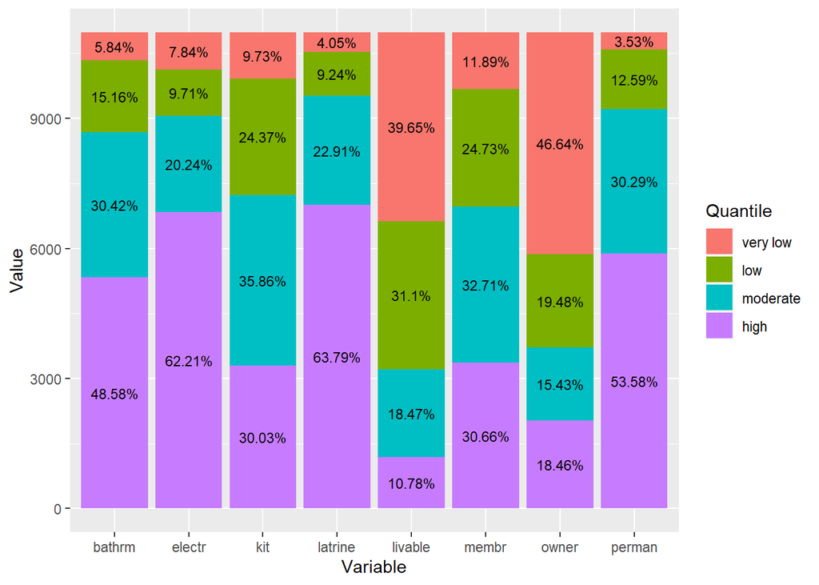

```r
lst2<-list()
i=1
for (i in 1:8){
  a<-as.data.frame.matrix(table(bihar1$TV,bihar1[,i+1]))
  a$New<-row.names(a)
  try<-subset(a,a$New=="high",select = c("very low","low","moderate","high"))
  try$new<-names(lst)[i]
  lst2[[i]]<-try
}

trydata<-do.call(rbind,lst2)

library(reshape2)
trydata<-melt(trydata)
names(trydata)<-c("Variable","Quantile","Value")

library(plyr)
trydata = ddply(trydata, .(Variable), transform, percent = Value/sum(Value) * 100)
trydata$label = paste(round(trydata$percent,2), "%",sep = "")

library(ggplot2)
ggplot(trydata, aes(fill=Quantile, y=Value, x=Variable,label=Value)) +
  geom_bar(position="stack", stat="identity")+
  geom_text(aes(label=label),size = 3, position = position_stack(vjust = 0.5))
```